# Examen 1 - Ejercicio 3

*175904 - Jorge III Altamirano Astorga*

*177508 - Uriel Miranda Miñón*

Datos de [MovieLens](http://movielens.org/)

## Carga de datos

```r
ratings <- read_csv("movielens/ratings.csv",
                  col_names = c("userId", "timestamp"),
                  col_types = "i__i",
                  # col_names = c("userId", "movieId", "rating", "timestamp"),
                  # col_types = "iidi",
                  skip =  1,
                  progress = F)
tags <- read_csv("movielens/tags.csv",
                  col_names = c("userId", "timestamp"),
                  col_types = "i--i",
                  # col_names = c("userId", "movieId", "tag", "timestamp"),
                  # col_types = "iici",
                  skip =  1,
                  progress = F)
nrow(ratings)
```

```
## [1] 20000263
```

```r
nrow(tags)
```

```
## [1] 465564
```

```r
ratings <- rbind(ratings, tags) %>%
  arrange(timestamp) %>%
  select(-timestamp) %>%
  rowid_to_column("id")
rm(tags)
nrow(ratings)
```

```
## [1] 20465827
```

```r
ratings %>% head(n=10)
```

| id | userId |
| --- | --- |
| 1 | 28507 |
| 2 | 131160 |
| 3 | 131160 |
| 4 | 131160 |
| 5 | 20821 |
| 6 | 53434 |
| 7 | 85252 |
| 8 | 85252 |
| 9 | 85252 |
| 10 | 85252 |

```r
summary(ratings)
```

```
##        id               userId
##  Min.   :       1   Min.   :     1
##  1st Qu.: 5116458   1st Qu.: 34307
##  Median :10232914   Median : 69182
##  Mean   :10232914   Mean   : 69038
##  3rd Qu.:15349370   3rd Qu.:103654
##  Max.   :20465827   Max.   :138493
```

Dividir el set en pruebas y validación.

```r
ratings_1 <- ratings[1:1E6,]
ratings_2 <- ratings[(1E6+1):nrow(ratings),]
summary(ratings_1)
```

```
##        id              userId
##  Min.   :      1   Min.   :     4
##  1st Qu.: 250001   1st Qu.: 35042
##  Median : 500000   Median : 69985
##  Mean   : 500000   Mean   : 69558
##  3rd Qu.: 750000   3rd Qu.:103992
##  Max.   :1000000   Max.   :138488
```

```r
summary(ratings_2)
```

```
##        id               userId
##  Min.   : 1000001   Min.   :     1
##  1st Qu.: 5866458   1st Qu.: 34248
##  Median :10732914   Median : 69124
##  Mean   :10732914   Mean   : 69012
##  3rd Qu.:15599370   3rd Qu.:103653
##  Max.   :20465827   Max.   :138493
```

## Conteos exactos

Del total

```r
n_users <- ratings$userId %>% unique %>% length
n_recor <- nrow(ratings)
sprintf("Se encontraron %d usuarios en %d registros. Proporción: %.3f",
        n_users,
        n_recor,
        n_users/n_recor)
```

```
## [1] "Se encontraron 138493 usuarios en 20465827 registros. Proporción: 0.007"
```

Del set de entrenamiento

```r
n_users <- ratings_1$userId %>% unique %>% length
n_recor <- nrow(ratings_1)
sprintf("Se encontraron %d usuarios en %d registros. Proporción: %.3f",
        n_users,
        n_recor,
        n_users/n_recor)
```

```
## [1] "Se encontraron 16710 usuarios en 1000000 registros. Proporción: 0.017"
```

Del set de prueba

```r
n_users <- ratings_2$userId %>% unique %>% length
n_recor <- nrow(ratings_2)
sprintf("Se encontraron %d usuarios en %d registros. Proporción: %.3f",
        n_users,
        n_recor,
        n_users/n_recor)
```

```
## [1] "Se encontraron 123704 usuarios en 19465827 registros. Proporción: 0.006"
```

Cambiamos los dataframes para que estén como texto la columna de User ID

```r
ratings_1$userId <- as.character(ratings_1$userId)
ratings_2$userId <- as.character(ratings_2$userId)
ratings_1 <- ratings_1[,2]
ratings_2 <- ratings_2[,2]
glimpse(ratings_1)
```

```
## Observations: 1,000,000
## Variables: 1
## $ userId <chr> "28507", "131160", "131160", "131160", "20821", "53434"...
```

```r
glimpse(ratings_2)
```

```
## Observations: 19,465,827
## Variables: 1
## $ userId <chr> "9294", "9294", "9294", "9294", "117707", "117707", "11...
```

## Conteo Probabilístico

### Buckets

```r
set.seed(752)
n <- 100000
m_bits <- 5
m <- 2^m_bits ## aprox 262,144
tail_length_lead <- function(bits){
  bits[-c(1:m_bits)] %>% which.max %>% as.integer
}
cubeta <- function(bits){
  paste(as.character(bits[1:m_bits]), collapse='')
}
armonica <- function(x){
  1/mean(1/x)
}
hash_gen <- function(seed){
  function(x){
    hash_32 <- digest::digest(x, 'xxhash32', serialize = FALSE, seed = seed)
    # Covertimos a bits, tomando de dos en dos:
    sapply(seq(1, nchar(hash_32), 2), function(x) substr(hash_32, x, x+1)) %>%
      strtoi(16L) %>%  # a enteros
      as.raw %>%    #bytes
      rawToBits()
    #dig_md5[permutacion]
  }
}
hash_1 <- hash_gen(seed = 752)
# n = log2(262144) #máx bits y cubetas
# n
# n_2 <- 5000
# ratings_1hll <- data_frame(num_distintos = 1:n_2) %>%
#       mutate(user_id = as.character(
#         ratings_1$userId[sample.int(nrow(ratings_1), n_2)]
#         )
#       ) %>%
#       mutate(tail = map_int(user_id, function(x) {
#                      hash_1(x) %>% tail_length_lead }),
#              cubeta = map_chr(user_id, function(x) {
#                     hash_1(x) %>% cubeta }),
#              tail_max = cummax(tail))
```

```r
ratings_hll <- ratings_1 %>%
      mutate(
        n_diferentes = 1:nrow(ratings_1),
        # n_diferentes = 1:100,map_chr(buckt_tail, function(x) x[2])
        buckt_tail = map(userId, function(x) {
          hash_x = hash_1(x)
          c(
            bucket = cubeta(hash_x),
            tail = tail_length_lead(hash_x)
          )
        }),
        bucket = map_chr(buckt_tail, function(x) x[1]),
        tail = map_chr(buckt_tail, function(x) x[2]))
ratings_hll <- ratings_hll[,c(1,2,4,5)]
ratings_hll$tail <- as.integer(ratings_hll$tail)
ratings_hll
```

[output not shown]

[output cut: 9990 more lines]

```r
ratings_hll$userId %>% unique %>% length
```

```
## [1] 16710
```

## Gráficas

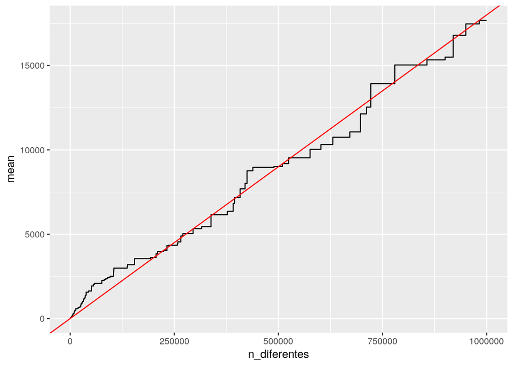

```r
graph <- ratings_hll[sample.int(nrow(ratings_hll), (nrow(ratings_hll)*0.1)),] %>%
  spread(bucket, tail, fill= 0) %>%
  gather(bucket, tail, -n_diferentes, -userId) %>%
  select(n_diferentes, bucket, tail)
graph <- graph %>%
  group_by(bucket) %>%
  arrange(n_diferentes) %>%
  mutate(tail_max = cummax(tail)) %>%
  group_by(n_diferentes) %>%
  summarise(mean = 0.72*(m*armonica(2^tail_max)))
ggplot(graph %>% filter(n_diferentes > 1000), aes(x = n_diferentes, y = mean)) +
  geom_line() +
  geom_abline(intercept = 0, slope = 0.018, colour ='red')
```

```r
quantile(1-graph$mean/graph$n_diferentes, probs=c(0.1, 0.5, .9))
```

```
##       10%       50%       90%
## 0.9734788 0.9820289 0.9833242
```

Error relativo

```r
1.04/sqrt(ratings_hll$bucket %>% unique %>% length)
```

```
## [1] 0.1838478
```

## Examen

1. Utiliza el algoritmo de hyperloglog para contar el número de usuarios distintos en los datos del ejercicio anterior, considerando que el flujo de datos son los ratings (ordénalos primero por timestamp). Utiliza el primer millón de observaciones. Haz una gráfica donde el eje horizontal es el número de elementos del flujo vistos y el eje vertical es la estimación de hyperloglog de usuarios únicos para cada momento.

*Se realizó en la sección de “Conteo Probabilístico”.*

2. Compara la estimación final de hyperloglog con el número de usuarios únicos (primer millón de observaciones ordenadas por timestamp).